# Testing for GxE interaction in structured populations

Andrey Ziyatdinov

May 5, 2017

## GxE interaction

Biological interaction: Genetic factor(s) and environmental factor(s) participate in the same causal mechanism in the same individual (Rothman *et al.*, 2008)

Statistical interaction (unrelated individuals) in linear regression:

$y = \mu + \beta_g x_g + \beta_e x_e + \beta_{int} x_g \times x_e + e$

$\mbox{where } e \sim (0, \sigma_r^2 I)$

(Aschard *et al.*, 2012, HumGen)

## Interesting to know, difficult to detect

(Aschard *et al.*, 2012, HumGen), (Kraft and Aschard, 2015, EurJEpi)

Relatedness is yet another layer of complexity in GxE analysis

## Relatedness in our analysis

- shared environment: house-hold groups
- recent genetic relatedness: family members
- distant genetic relatedness: admixed populations

## Relatedness in association tests

Methods to account for relatedness are relatively well established  
in *marginal* association studies (GWAS)

- Principal component analysis (PCA)
- Linear mixed models (LMMs) (Yang *et al.*, 2014)
- Robust tests: genotype-conditional association test (GCAT) (Song *et al.*, 2015, NatGen)

## Relatedness in interaction tests (stratified)

1. Compute marginal genetic effects in stratas, e.g., males and females
   - $\beta_m$ and $\beta_f$, the genetic effects
   - $\sigma_{\beta_m}$ and $\sigma_{\beta_f}$, their standard errors
2. Combine stratified results and perform tests
   - strata-specific, **interaction** (differentiated), joint, heterogeneity

| Stratas | Stratified interaction test | Reference |
| --- | --- | --- |
| Idependent | $Z_{int} = \frac{\beta_m - \beta_f}{\sqrt{\sigma_{\beta_m}^2 + \sigma_{\beta_f}^2}} \sim \mathcal{N}(0, 1)$ | (Magi *et al.*, 2010) |
| Related | $Z_{int} = \frac{\beta_m - \beta_f}{\sqrt{\sigma_{\beta_m}^2 + \sigma_{\beta_f}^2 + r \sigma_{\beta_m} \sigma_{\beta_f}}} \sim \mathcal{N}(0, 1)$ | (Randall *et al.*, 2013) |

$r$ is the spearman correlation between the two tests

- a naive approach that needs further investigation (Sofer *et al.*, 2016, GenEpi)
- methodology is similar to multi-trait meta-analysis (Zhu *et al.*, 2016, AJHG)

## Stratified GxE tests are widely used in meta-analysis by big consortia

[figure not shown]

(Heid *et al.*, 2010), Genetic Investigation of Anthropometric Traits (GIANT) consortium

## Our goal

Assess the relative performance of GxE methods  
in the presence of structure

- derive re-derive formulas for $\hat{\beta}_{int}$ and $var(\hat{\beta}_{int})$
- assess statistical power
- guide the methodological choice: standard vs. stratified

## Our methods

- Simulate related individuals with GxE interactions
  - shared environments, family-based, admixed (to be done)
- Fit data to estimate the interaction effect by linear mixed models
  - lme4qtl R package
- Compare interaction tests when relatedness is presented
  - Compare two study designs unrelated/related

## Experimental set up

Given: a population of 50,000 related samples (nuclear families)

Experiment: pool 5,000 unrelated samples or pool randomly

| relatedness | $V$ | $\Sigma_x$ | Normalization |
| --- | --- | --- | --- |
| unrelated | $\sigma_g^2 K + \sigma_r^2 I = (\sigma_g^2 + \sigma_r^2) I$ | $\sigma_x I$ | $\sigma_g^2 + \sigma_r^2 = 1$ |
| genetically related | $\sigma_g^2 K + \sigma_r^2 I$ | $\sigma_x K$ | $\sigma_g^2 + \sigma_r^2 = 1$ |

- $K$, the double kinship matrix
- $\Sigma_x$, the variance-covariance matrix of predictor $x$
- $\sigma_g^2$, $\sigma_r^2$, variance proportions

## Problem statement

|  | Problem 1 | Problem 2 | Problem 3 |
| --- | --- | --- | --- |
| Sample | Family-based | Population-based | Population-based |
| Relationships | Kinship |  | GRM |
| Method | Linear mixed models | Linear models | Linear mixed models |

Problems 2 *vs.* 3 (Yang *et al.*, 2014)

## GWAS with related individuals

[figure not shown]

## Outline

- **Mixed models for marginal/interaction effects**
- Stratified GxE tests in related individuals
- GxE tests in admixed population
- lme4qtl R package

Power of the Wald test in unrelated/genetically related using simulations ($h^2$ = 0.1, 06, 0.9)

- The power in unrelated is always higher
- The power in genetically related depdends on the heritability non-linearly

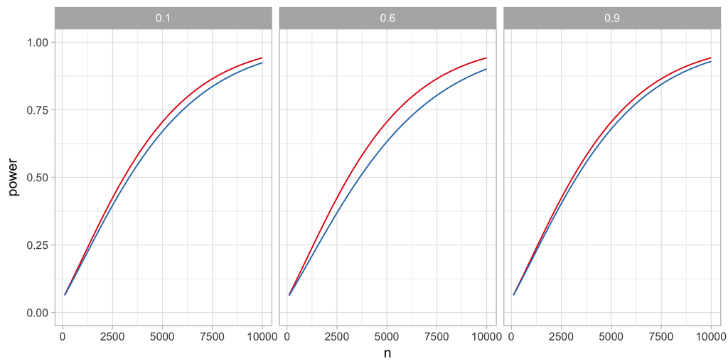

## Linear mixed models (LMMs) (also our data simulation model)

$y = \mu + \beta_g x_g + g + f + e$  
$\mbox{ } \mbox{ } = X \beta + g + f + e$

$\mbox{where } g \perp f \perp e$

- $g \sim (0, \sigma_g^2 K)$, the (additive) genetic effect
- $h \sim (0, \sigma_f^2 F)$, the house-hold/family effect
- $e \sim (0, \sigma_r^2 I)$, the residual error

$\mbox{implying}$

$y \sim (X \beta, \sigma_g^2 K + \sigma_f^2 F + \sigma_r^2 I) = (X \beta, V)$

(Lynch and Walsh, 1998)

## Marginal effect estimate

1. Estimate variance components by ML/REML

$\hat{V} = \hat{\sigma_g^2} K + \hat{\sigma_f^2} F + \hat{\sigma_r^2} I$

2. Estimate the effect size as in Generalized Least Squares (GLS)

$\hat{\beta}_g = (X^T \hat{V}^{-1} X)^{-1} X^T \hat{V}^{-1} Y \sim (\beta, (X^T \hat{V}^{-1} X)^{-1})$

3. Simplify to a one-covariate model by orthogonalization
- the original model: $E(Y) = \mu + \beta_g x_g$
- $y^*$, centered $y$
- $x^*_g$, centered $x_g$

$var(\hat{\beta}_g) = ({x^*_g}^T \hat{V}^{-1} x^*_g)^{-1}$

## Power

The power in genetic association studies with linear models is a function of the non-centrality parameter (NCP)

$NCP \approx \beta^2 tr(\hat{V}^{-1} \Sigma_x)$

| Data | Model |
| --- | --- |
| phenotype | $y \sim (X \beta, V) = (X \beta, \sigma_f^2 F + \sigma_g^2 K + \sigma_r^2 I)$ |
| genotypes | $x \sim (\mu_x, \Sigma_x)$ |

# Thank you

# Extra slides

## GAIT2 Spanish families (previous project)

The Genetic Analysis of Idiopathic Thrombophilia 2 (GAIT2) Project

- Study of Venous Thrombosis
  - disease prevalence <1%
  - heritability $\sim$ 60%
- 935 individuals in 35 families (27 per family on average)
- Hundreds of phenotypes (blood coagulation system)
- Genotype and RNA-seq data

Developed tools for analysis of family-based samples

- [solarius](https://github.com/ugcd/solarius/) R package [makes SOLAR easier to use]
- lme4qtl R package [makes lme4 flexible]

## COPDgene African-Americans (current project)

COPDgene dataset

- 3,300 admixed African-Americans
- a set of COPD outcomes/exposures
- SNPs, inferred local/global ancestry

Previous studies reported

- Smoking is the major risk factor
- African ancestry associated with increased risk of COPD

The project aims at leveraging the ancestry information in GxE tests

- global ancestry $\times$ exposure
- local ancestry $\times$ exposure
- SNP $\times$ exposure